# ps5

Katherine Guo

2023-02-19

## 1 Load and check data(5pt)

#### 1.2

```r
library(readr)
gapminder <- read.delim("C:/Users/Katherine Guo/Desktop/info 201/ps05-rmarkdown-plot/gapminder.csv/gapminder.csv")

nrow(gapminder)
```

```
## [1] 13055
```

```r
ncol(gapminder)
```

```
## [1] 25
```

#### 1.3

Prints a small sample of data The data looks OK.

```r
head(gapminder)
```

```
##   iso3  name iso2   region                      sub.region intermediate.region
## 1  ABW Aruba   AW Americas Latin America and the Caribbean           Caribbean
## 2  ABW Aruba   AW Americas Latin America and the Caribbean           Caribbean
## 3  ABW Aruba   AW Americas Latin America and the Caribbean           Caribbean
## 4  ABW Aruba   AW Americas Latin America and the Caribbean           Caribbean
## 5  ABW Aruba   AW Americas Latin America and the Caribbean           Caribbean
## 6  ABW Aruba   AW Americas Latin America and the Caribbean           Caribbean
##   time totalPopulation fertilityRate lifeExpectancy childMortality
## 1 1960           54211         4.820         65.662             NA
## 2 1961           55438         4.655         66.074             NA
## 3 1962           56225         4.471         66.444             NA
## 4 1963           56695         4.271         66.787             NA
## 5 1964           57032         4.059         67.113             NA
## 6 1965           57360         3.842         67.435             NA
##   youthFemaleLiteracy youthMaleLiteracy adultLiteracy GDP_PC accessElectricity
```

[output cut: 20 more lines]

## 2. Descriptive statistics(15pt)

#### 2.1 iso3: 253 iso2: 249 name: 250

```r
library(dplyr)
gapminder %>%
  select(iso3, iso2, name) %>%
  summarise(n1 =n_distinct(iso3), n2 = n_distinct(iso2), n3 = n_distinct(name))
```

```
##    n1  n2  n3
## 1 253 249 250
```

#### 2.2 (a) The table below shows how many names are there for each iso-2 code. There is one iso-2 codes that correspond to more than one name, *Namibia*.

```r
gapminder %>%
  select(name, iso2) %>%
  group_by(iso2) %>%
  summarise(unique = n_distinct(name), name = paste(unique(name), collapse = ", ")) %>%
  arrange(desc(unique))
```

```
## # A tibble: 249 × 3
##    iso2  unique name
##    <chr>  <int> <chr>
##  1 ""         2 , Namibia
##  2 "AD"       1 Andorra
##  3 "AE"       1 United Arab Emirates
##  4 "AF"       1 Afghanistan
##  5 "AG"       1 Antigua and Barbuda
##  6 "AI"       1 Anguilla
##  7 "AL"       1 Albania
##  8 "AM"       1 Armenia
##  9 "AO"       1 Angola
## 10 "AQ"       1 Antarctica
## # … with 239 more rows
```

```r
gapminder %>%
  group_by(name, iso3) %>%
  summarise(number = n_distinct(iso3), .groups = "drop") %>%
  arrange(desc(number))
```

```
## # A tibble: 253 × 3
##    name             iso3        number
##    <chr>            <chr>        <int>
##  1 ""               CHANISL          1
##  2 ""               GBM              1
##  3 ""               KOS              1
##  4 ""               NLD_CURACAO      1
##  5 "Afghanistan"    AFG              1
##  6 "Albania"        ALB              1
##  7 "Algeria"        DZA              1
##  8 "American Samoa" ASM              1
##  9 "Andorra"        AND              1
## 10 "Angola"         AGO              1
## # … with 243 more rows
```

#### 2.3 The minimum year is: 1960 The maximum year is: 2019

```r
gapminder %>%
  select(time) %>%
  filter(!is.na(time)) %>%
  summarise(min(time), max(time))
```

```
##   min(time) max(time)
## 1      1960      2019
```

## 3 CO2 emissions(30pt)

#### 3.1 Year **2017**,**2018**,**2019** have most missing data.

```r
gapminder %>%
  group_by((time)) %>%
  summarise(missing_co2 = sum(is.na(co2)), missing_co2pc = sum(is.na(co2_PC))) %>%
  arrange(desc(missing_co2 + missing_co2pc))
```

```
## # A tibble: 61 × 3
##    `(time)` missing_co2 missing_co2pc
##       <int>       <int>         <int>
##  1     2017         217           217
##  2     2018         217           217
##  3     2019         217           217
##  4     1960          60            60
##  5     1961          60            60
##  6     1962          58            58
##  7     1963          57            57
##  8     1964          51            51
##  9     1965          51            51
## 10     1966          51            51
## # … with 51 more rows
```

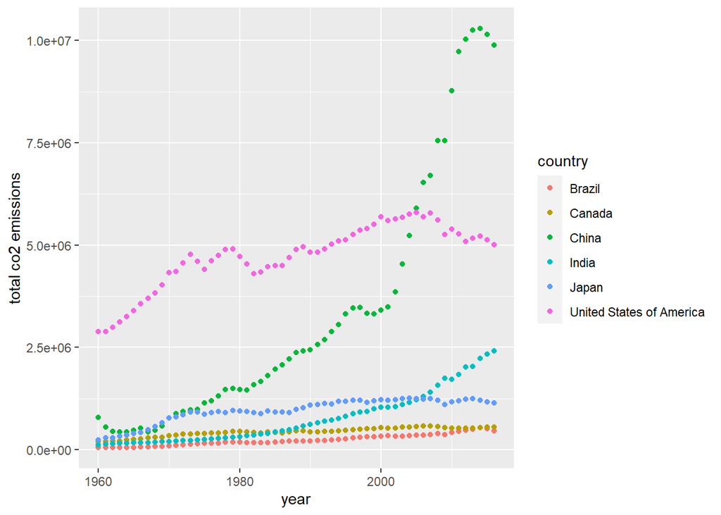

```r
library(ggplot2)
gapminder %>%
  filter(name %in% c("United States of America", "China", "India",
                     "Brazil", "Japan", "Canada"), !is.na(co2)) %>%
  ggplot(aes(x = time, y = co2, color = name)) + geom_point() +
           labs(x = "year", y = "total co2 emissions", color = "country")
```

#### 3.3 From the plot figure, U.S. and Canada has much higher CO2 emissions per capita compared to China, India, Brazil, and Japan. Both India and Brazil have very stable growing.China has its sudden increase started from 2000. But there has gradually decrease in CO2 emissions per capita for some of the coutries in this plot.

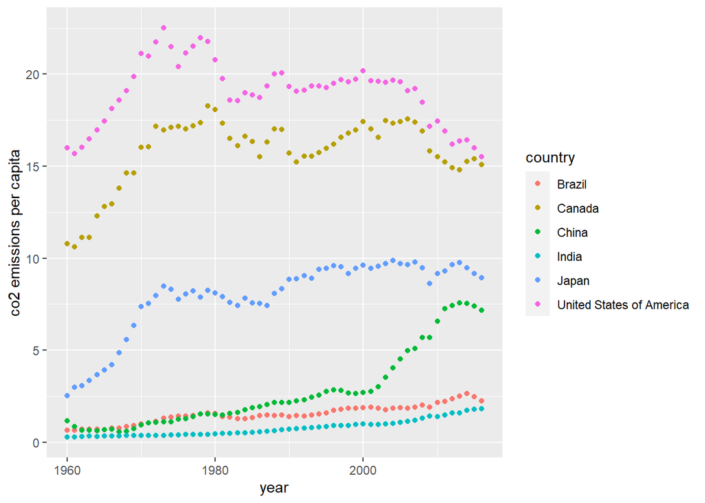

```r
gapminder %>%
  filter(name %in% c("United States of America", "China", "India",
                     "Brazil", "Japan", "Canada"), !is.na(co2_PC)) %>%
  ggplot(aes(x = time, y = co2_PC, color = name)) + geom_point() +
           labs(x = "year", y = "co2 emissions per capita", color = "country")
```

#### 3.4 Based on the calculated data, I see the average CO2 emissions per capita differ from each regions a lot. **Europe** has the highest average CO2_PC with 7.95. **Africa** has the lowest with 0.93.(This calculation only considers the average emissions per capita for each country, doesn’t account for the countries are of different size within each region).

```r
gapminder %>%
  group_by(region) %>%
  filter(!is.na(region), region != "") %>%
  summarise(avg_co2PC = round(mean(co2_PC, na.rm = TRUE), 2))
```

```
## # A tibble: 5 × 2
##   region   avg_co2PC
##   <chr>        <dbl>
## 1 Africa        0.93
## 2 Americas      6.46
## 3 Asia          6.21
## 4 Europe        7.95
## 5 Oceania       4.39
```

#### 3.5 Below is a barplot that shows the results of average CO2 emissions per capita aross continent in *1960* and *2016*.

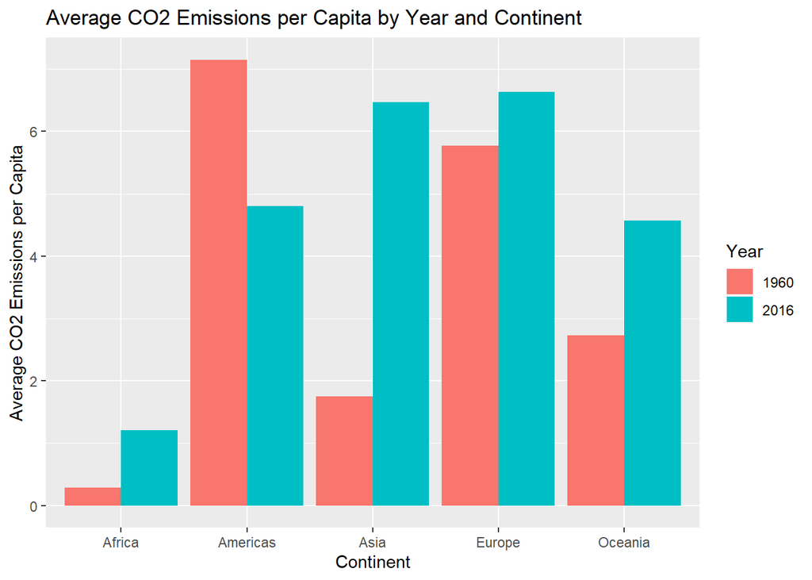

```r
gapminder %>%
  filter(time %in% c(1960, 2016), !is.na(region), !is.na(co2_PC)) %>%
  filter(region != "") %>%
  group_by(time, region) %>%
  summarise(avg_co2PC = mean(co2_PC), .groups = "drop")%>%
  ggplot(aes(x = region, y = avg_co2PC, fill = as.factor(time))) +
  geom_col( position = "dodge") +
   labs(title = "Average CO2 Emissions per Capita by Year and Continent",
       x = "Continent",
       y = "Average CO2 Emissions per Capita") +
  scale_fill_discrete( name = "Year")
```

#### 3.6 It seems like data for 2019 is missing, then I use 2016. This table shows the *three largest* and *three smallest* CO2 emitters(based on CO2 per capita) in 2016 for each region. It is arranged by largest to smallest in terms of region.

```r
library(dplyr)
gm_2016 <- gapminder %>% filter(time == 2016, !is.na(co2_PC), region != "")

largest_3 <- gm_2016 %>%
  group_by(region) %>%
  top_n(3, co2_PC) %>%
  arrange(region, desc(co2_PC)) %>%
  select(region, name, co2_PC) %>%
  ungroup()

smallest_3 <- gm_2016 %>%
  group_by(region) %>%
  top_n(-3, co2_PC) %>%
  arrange(region, co2_PC) %>%
  select(region, name, co2_PC) %>%
  ungroup()

large_small <- rbind(largest_3, smallest_3)
large_small
```

```
## # A tibble: 30 × 3
##    region   name                     co2_PC
##    <chr>    <chr>                     <dbl>
##  1 Africa   South Africa               8.48
##  2 Africa   Libya                      7.79
##  3 Africa   Seychelles                 6.39
##  4 Americas Trinidad and Tobago       31.8
##  5 Americas United States of America  15.5
##  6 Americas Canada                    15.1
##  7 Asia     Qatar                     38.9
##  8 Asia     Kuwait                    25.0
##  9 Asia     Bahrain                   22.2
## 10 Europe   Gibraltar                 18.8
## # … with 20 more rows
```

## 4 GDP per capita(50pt)

#### 4.1 From the scatterplot, It could see that there is a positive correlation between **GDP per capita** and **life expectancy** in 1960. We also can see the countries with the highest GDP per capita are mostly located in Europe and Americas.The lowest appears in Asia and Africa.

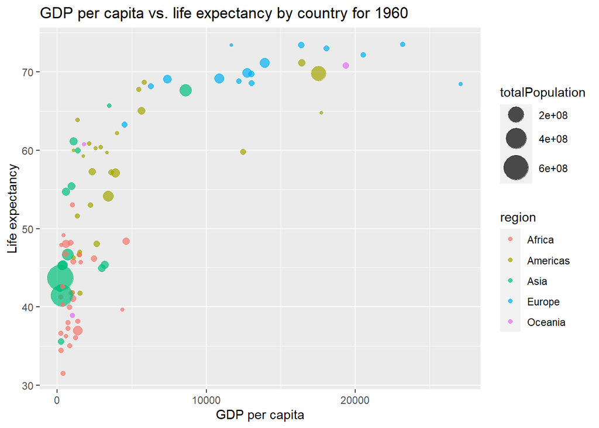

```r
gapminder_1960 <- gapminder[gapminder$time == 1960,]
  ggplot(gapminder_1960 %>%  filter(!is.na(region), region != "", !is.na(GDP_PC), !is.na(lifeExpectancy)), aes(x = GDP_PC, y = lifeExpectancy,
                           size = totalPopulation, color = region)) +
  geom_point(alpha = 0.7) +
  scale_size_continuous(range = c(1, 10))+
  xlab("GDP per capita") +
  ylab("Life expectancy")+
  ggtitle("GDP per capita vs. life expectancy by country for 1960")
```

#### 4.2 In the scatterplot for 2019, It could see a increasing trend of life expectancy with GDP per capita. The range is wider. Asia has increasing life expectancy.

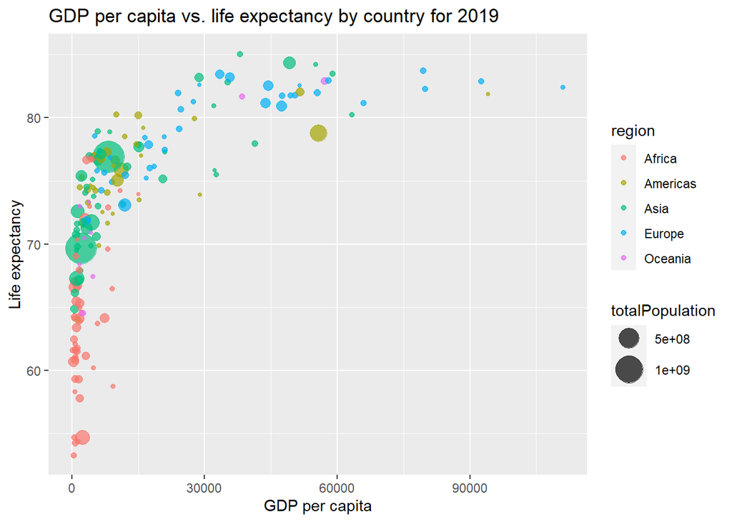

```r
gapminder_2019 <- gapminder[gapminder$time == 2019,]
  ggplot(gapminder_2019 %>%  filter(!is.na(region), region != "", !is.na(GDP_PC), !is.na(lifeExpectancy)), aes(x = GDP_PC, y = lifeExpectancy,
                           size = totalPopulation, color = region)) +
  geom_point(alpha = 0.7) +
  scale_size_continuous(range = c(1, 10))+
  xlab("GDP per capita") +
  ylab("Life expectancy")+
  ggtitle("GDP per capita vs. life expectancy by country for 2019")
```

#### 4.3 Comparing the two scatterplot, they shows a positive correlation between **GDP per capita** and **life expectancy** during the last 60 years. In 1960, the difference between each continent is obvious. However, in 2019, we could see the differences has narrowed, the region has lower GDP and life expectancy has grow. It shows the world has made significant development in terms of economics and other social aspects. It still have a lot of room to improve in the future.

4.4 The result fits what I observed from the previous scatterplots. It shows that the *life expectancy* has increased for all continents between 1960 to 2019.

```r
gapminder %>%
  filter(time %in% c(1960, 2019), !is.na(lifeExpectancy), !is.na(region), region != "") %>%
  group_by(region, time) %>%
  summarise(avg_LE = round(mean(lifeExpectancy), 1))
```

```
## # A tibble: 10 × 3
## # Groups:   region [5]
##    region    time avg_LE
##    <chr>    <int>  <dbl>
##  1 Africa    1960   41.5
##  2 Africa    2019   64.1
##  3 Americas  1960   58.6
##  4 Americas  2019   75.8
##  5 Asia      1960   51.6
##  6 Asia      2019   74.6
##  7 Europe    1960   68.3
##  8 Europe    2019   79.4
##  9 Oceania   1960   56.4
## 10 Oceania   2019   73.5
```

#### 4.5 This table shows the average LE growth from *1960-2019* across the continents in the order of growth. Asia has the highest rate of improvement in 2019, Africa had the lowest average life expectancy in both 1960 and 2019. Europe has the highest life expectancy in both 1960 and 2019, but has the slowest rate of growth.

```r
gapminder %>%
  filter(time %in% c(1960, 2019), !is.na(lifeExpectancy), !is.na(region), region != "") %>%
  group_by(region, time) %>%
  summarise(avg_LE = round(mean(lifeExpectancy),1)) %>%
  mutate(prev = lag(avg_LE), growth = avg_LE - prev) %>%
  arrange(desc(growth))
```

```
## # A tibble: 10 × 5
## # Groups:   region [5]
##    region    time avg_LE  prev growth
##    <chr>    <int>  <dbl> <dbl>  <dbl>
##  1 Asia      2019   74.6  51.6   23
##  2 Africa    2019   64.1  41.5   22.6
##  3 Americas  2019   75.8  58.6   17.2
##  4 Oceania   2019   73.5  56.4   17.1
##  5 Europe    2019   79.4  68.3   11.1
##  6 Africa    1960   41.5  NA     NA
##  7 Americas  1960   58.6  NA     NA
##  8 Asia      1960   51.6  NA     NA
##  9 Europe    1960   68.3  NA     NA
## 10 Oceania   1960   56.4  NA     NA
```

#### 4.6 This histogram shows GDP per capita for years of *1960* and *2019*.

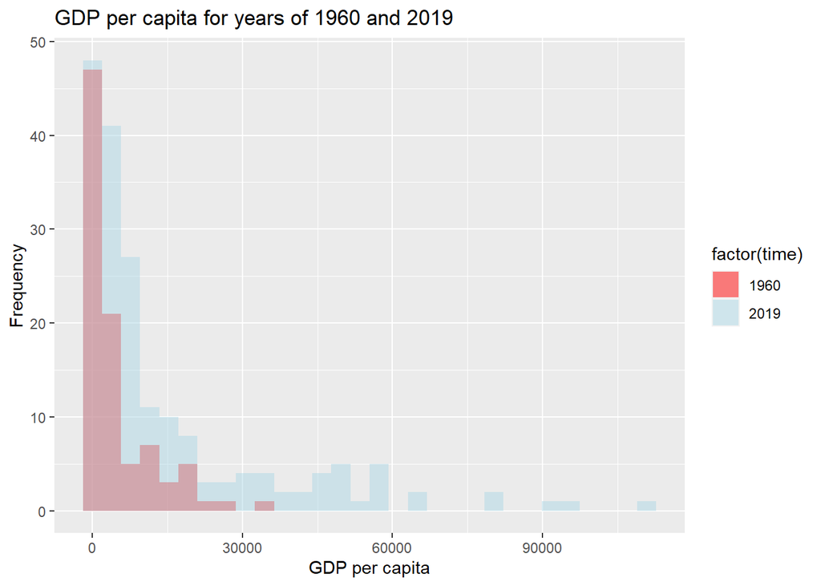

```r
library(ggplot2)
ggplot(data = gapminder %>% filter(time %in% c(1960, 2019), !is.na(GDP_PC)), aes(x = GDP_PC, fill = factor(time))) +
  geom_histogram(alpha = 0.5, bins = 30, position = "identity") +
  scale_fill_manual(values = c("red", "lightblue")) +
  ggtitle("GDP per capita for years of 1960 and 2019") +
  xlab("GDP per capita") +
  ylab("Frequency")
```

#### 4.7 US life expectancy ranking in 1960: **17** US life expectancy ranking in 2019: **46**

```r
gapminder %>%
  filter(!is.na(lifeExpectancy), name != "", region != "") %>%
  group_by(time) %>%
  arrange(desc(lifeExpectancy)) %>%
  mutate(rank = dense_rank(desc(lifeExpectancy))) %>%
  filter(time %in% c("1960", "2019"), name == "United States of America") %>%
  summarise(rank = rank[1])
```

```
## # A tibble: 2 × 2
##    time  rank
##   <int> <int>
## 1  1960    17
## 2  2019    46
```

#### 4.8 The relative rank for 1960: **0.0904** The relative rank for 2019: **0.2347**

```r
gapminder %>%
  filter(!is.na(lifeExpectancy), region != "") %>%
  group_by(time) %>%
  summarise(n_countries = n_distinct(name)) %>%
  left_join(
    gapminder %>%
      filter(!is.na(lifeExpectancy), region != "") %>%
      arrange(time, desc(lifeExpectancy)) %>%
      group_by(time) %>%
      mutate(rank = dense_rank(desc(lifeExpectancy))) %>%
      filter(name == "United States of America") %>%
      select(time, rank),
    by = "time"
  ) %>%
  mutate(rel_rank = round(rank/n_countries, 4)) %>%
  filter(time %in% c("1960", "2019")) %>%
  select(time, rank, rel_rank)
```

```
## # A tibble: 2 × 3
##    time  rank rel_rank
##   <int> <int>    <dbl>
## 1  1960    17   0.0904
## 2  2019    46   0.235
```